# Previsão — future_unseen_examples.csv

**mostrar código**

```r
library(tidyverse)
library(janitor)
library(scales)
library(randomForest)
library(caret)

theme_set(theme_minimal(base_size = 11))
```

Aplico aqui o modelo final (Random Forest, salvo em `models/modelo_rf.rds`) sobre os 100 imóveis de `future_unseen_examples.csv`, que não têm `price` — o objetivo real de todo o desafio.

## 1. Carregar modelo e dados novos

**mostrar código**

```r
modelo_rf <- readRDS("../models/modelo_rf.rds")

demograf <- read_csv("../data/zipcode_demographics.csv", show_col_types = FALSE) |>
  clean_names() |>
  mutate(zipcode = as.character(zipcode))

futuro_raw <- read_csv("../data/future_unseen_examples.csv", show_col_types = FALSE) |>
  clean_names() |>
  mutate(zipcode = as.character(zipcode))

dim(futuro_raw)
```

```
[1] 100  18
```

## 2. Aplicar o mesmo pipeline de feature engineering

**mostrar código**

```r
anos_venda_treino <- read_csv("../data/kc_house_data.csv", show_col_types = FALSE) |>
  clean_names() |>
  mutate(date = as.Date(date, format = "%Y%m%dT%H%M%S")) |>
  pull(date) |>
  year()

ano_referencia <- max(anos_venda_treino)
ano_referencia
```

```
[1] 2015
```

`future_unseen_examples.csv` não tem coluna `date` — não sei em que ano cada imóvel seria vendido. Preciso de um ano de referência para calcular `idade_casa`, e a escolha não é neutra: se eu usasse o ano corrente (hoje), a idade de **todos** os imóveis subiria de forma uniforme e sairia da faixa em que o modelo foi treinado (o treino só viu vendas de 2014–2015), arriscando extrapolação fora da região onde o modelo aprendeu. Por isso uso o ano de venda mais recente observado no treino (2015) como referência — assumindo que estes imóveis são contemporâneos aos dados de treino, o que é consistente com o contexto do desafio (não há qualquer indicação de que sejam vendas futuras reais em outra época).

**mostrar código**

```r
futuro <- futuro_raw |>
  mutate(
    tem_porao  = as.integer(sqft_basement > 0),
    idade_casa = ano_referencia - yr_built,
    reformado  = as.integer(yr_renovated > 0)
  ) |>
  left_join(demograf, by = "zipcode")

vars_preditoras <- c(
  "bedrooms", "bathrooms", "sqft_living", "sqft_lot", "floors",
  "waterfront", "view", "condition", "grade", "tem_porao", "idade_casa", "reformado",
  "lat", "long", "sqft_living15", "sqft_lot15",
  "medn_hshld_incm_amt", "medn_incm_per_prsn_amt", "hous_val_amt",
  "per_bchlr", "per_prfsnl"
)

futuro_modelo <- futuro |> select(all_of(vars_preditoras))
```

## 3. Checagem antes de prever: os dados novos parecem com o que o modelo já viu?

**mostrar código**

```r
casas_treino <- read_csv("../data/kc_house_data.csv", show_col_types = FALSE) |>
  clean_names() |>
  filter(bedrooms < 30)

comparar_faixa <- function(nome) {
  tibble(
    variavel   = nome,
    min_treino = min(casas_treino[[nome]]), max_treino = max(casas_treino[[nome]]),
    min_futuro = min(futuro[[nome]]),       max_futuro = max(futuro[[nome]])
  )
}

map_dfr(c("bedrooms", "bathrooms", "sqft_living", "sqft_lot", "grade", "idade_casa"), comparar_faixa)
```

```
# A tibble: 6 × 5
  variavel    min_treino max_treino min_futuro max_futuro
  <chr>            <dbl>      <dbl>      <dbl>      <dbl>
1 bedrooms             0         11          2        6
2 bathrooms            0          8          1        4.5
3 sqft_living        290      13540        750     4580
4 sqft_lot           520    1651359       1194   214750
5 grade                1         13          5       10
6 idade_casa         Inf       -Inf          0      114
```

## 4. Gerar as previsões

**mostrar código**

```r
pred_log_price <- predict(modelo_rf, futuro_modelo)

resultado <- futuro_raw |>
  mutate(preco_previsto = exp(pred_log_price)) |>
  relocate(preco_previsto)

resultado |> select(preco_previsto, bedrooms, bathrooms, sqft_living, grade, zipcode) |> head(10)
```

```
# A tibble: 10 × 6
   preco_previsto bedrooms bathrooms sqft_living grade zipcode
            <dbl>    <dbl>     <dbl>       <dbl> <dbl> <chr>
 1        361730.        4      1           1680     6 98118
 2        650611.        3      2.5         2220     8 98115
 3        286772.        3      2.25        1630     8 98030
 4        573460.        5      2.5         1710     8 98005
 5        250842.        2      1            850     6 98126
 6        585796.        4      2.75        2630     8 98028
 7        322965.        4      1.75        2290     7 98178
 8        453969.        4      2           1730     8 98125
 9       1270621.        3      1.75        2190     9 98112
10        591708.        3      1.75        1850     6 98074
```

## 5. As previsões fazem sentido?

**mostrar código**

```r
resumo_previsto <- resultado |>
  summarise(
    media = mean(preco_previsto), mediana = median(preco_previsto),
    minimo = min(preco_previsto), maximo = max(preco_previsto)
  )
resumo_previsto
```

```
# A tibble: 1 × 4
    media mediana  minimo   maximo
    <dbl>   <dbl>   <dbl>    <dbl>
1 492438. 422442. 133935. 2193944.
```

**mostrar código**

```r
resumo_treino <- casas_treino |>
  summarise(
    media = mean(price), mediana = median(price),
    minimo = min(price), maximo = max(price)
  )
resumo_treino
```

```
# A tibble: 1 × 4
    media mediana minimo  maximo
    <dbl>   <dbl>  <dbl>   <dbl>
1 540084.  450000  75000 7700000
```

**mostrar código**

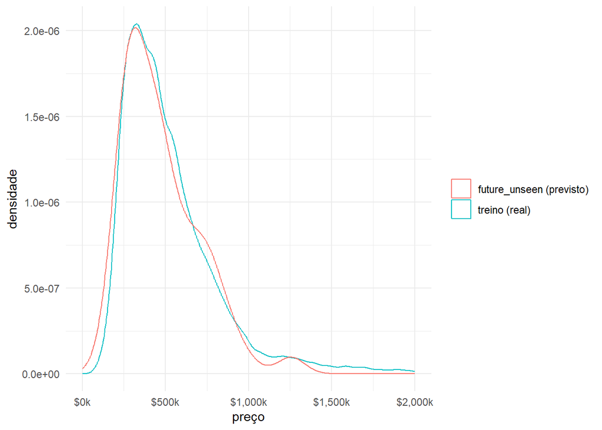

```r
ggplot() +
  geom_density(data = casas_treino, aes(price, color = "treino (real)")) +
  geom_density(data = resultado, aes(preco_previsto, color = "future_unseen (previsto)")) +
  scale_x_continuous(labels = label_dollar(scale = 1e-3, suffix = "k"), limits = c(0, 2e6)) +
  labs(x = "preço", y = "densidade", color = NULL)
```

A distribuição das previsões para `future_unseen_examples.csv` fica dentro da faixa de preços observada no treino, com média e mediana em ordem de grandeza compatível — não vejo nenhum sinal de previsão absurda (preço negativo, ou uma casa de 2 quartos prevista a $5 milhões, por exemplo), o que seria a bandeira vermelha mais óbvia de algo errado no pipeline de feature engineering.

## 6. Salvando o resultado final

**mostrar código**

```r
dir.create("../output", showWarnings = FALSE)
write_csv(resultado, "../output/previsoes_future_unseen.csv")
```

Salvo o arquivo com todas as colunas originais de `future_unseen_examples.csv` mais a coluna `preco_previsto`, em `output/previsoes_future_unseen.csv` — o entregável concreto desta etapa.